# Zhang-EndorserMessageCharacteristics-2025-IMDS.pdf

Converted from PDF `Zhang-EndorserMessageCharacteristics-2025-IMDS.pdf` · 43 pages · anchors: page `#pN`, block `#pN-bK`

Page 1

Industrial Management & Data Systems

https://doi.org/10.1108/IMDS-01-2025-0094

*'This author accepted manuscript is deposited under a Creative Commons Attribution Non-commercial 4.0*

*International (CC BY-NC) licence. This means that anyone may distribute, adapt, and build upon the work for*

*non-commercial purposes, subject to full attribution. If you wish to use this manuscript for commercial*

*purposes,* *please visit Marketplace**'*

### **When does Endorsement Work? The Moderating Role of Endorser and**

### **Message Characteristics**

Yimiao Zhang, Singapore University of Social Sciences

Chien-hui Chuang, Tunghai University

Yan Lin, University of Macau

### **Abstract**

**Purpose:** This study explores how both endorser and message characteristics moderate the effectiveness of

influencer endorsements.

**Design and methodology:** We adopted a quasi-experimental design to track endorsement events on social media

and corresponding sales data from e-commerce platforms. Difference-in-difference (DID) models and regression

analysis were used to examine the effects of celebrity endorsements and the moderating effects of various endorser

and message characteristics.

**Findings:** We find that only influencers with over 10,000 followers significantly drive sales. Additionally,

frequent endorsements by the same influencer are less effective. In terms of message characteristics, imagery and

overt endorsements are found to be more effective than their text-only and subtle counterparts.

**Originality:** This study contributes to the influencer marketing literature by revealing the role of endorser and

message characteristics in influencing the effectiveness of online influencer endorsements, and by quantifying the

impact of online influencer endorsements on actual sales.

**Practical Implications:** On average, influencers with less than ten thousand followers are unlikely to drive

significant sales. Influencers need to be more strategic in their endorsement activities, as frequent endorsements

can be detrimental. Overt and imagery endorsement messages are more effective than covert and text-only ones.

**Keywords:** online influencer endorsement, social media, e-commerce, field study

**Accepted**: 18 October 2025/ **Published**: 25 November 2025

Page 2

### **1. Introduction**

For decades, companies have adopted celebrity endorsement by hiring actors/actresses, singers, and athletes to

promote their products through mass media (Erdogan 1999). While such practices are still prevalent today, many

companies now complement them with social media strategies to reach younger consumers, who increasingly rely

on social media for shopping decisions. As part of this shift, firms are partnering with online influencers to

promote their products on platforms like Twitter, Instagram, TikTok, and Weibo (De Veirman et al. 2017, Hwang

and Jeong 2016, Brison et al. 2016, Jin and Phua 2014, Yang and Ha 2021). The estimated global influencer

marketing expense reached 30.81 billion USD with per internet user spending at 5.29 USD in 2023, and it is

forecasted to reach 39.33 billion USD by 2025, according to a market research report by Statistia (Statista 2025).

Influencer marketing is “a strategy in which a firm selects and incentivizes online influencers to engage their

followers on social media in an attempt to leverage these influencers’ unique resources to promote the firm’s

offerings” (Leung et al. 2022b, pp. 1). This approach is similar to traditional celebrity endorsement strategies but

is adapted to the social media context (Bergkvist and Zhou 2016). Online influencers promote a firm’s offerings

with the purpose of increasing consumers’ purchase intentions and, ultimately, enhancing the firm’s performance

through endorsement activities conducted on social media platforms.

An online endorsement comprises two key components: the endorser, who serves as the source of the message,

and the endorsement message itself. Scholars have examined various factors that are either from endorser or

message perspective. Regarding the endorser , follower size remains a key factor for marketers when selecting

influencers for marketing campaigns, as their effectiveness is largely driven by the influencers' fanbase (De

Veirman et al. 2017, Jin and Phua 2014, Cascio Rizzo et al. 2023b). While influencer follower size has received

substantial attention in the literature as a critical factor, findings remain mixed and inconclusive (Kay et al. 2020,

Leung et al. 2022a, Park et al. 2021). For example, while Leung et al. (2022a) finds that follower size enhance

endorsement effectiveness, Kay et al. (2020) finds the micro influencer – those with fewer followers are more

effective in endorsing products. Beyond follower size, however, endorsement frequency — defined as the

proportion of endorsements relative to an account’s overall posting activity — has received limited attention in

influencer marketing research. Meanwhile, endorsement message is equally important in determining its

effectiveness. Past studies have examined the effects of the language used in an endorsement (Cascio Rizzo et al.

2023b, Cascio Rizzo et al. 2023a), the tone of the messages (Jin and Phua 2014), and the disclosure of

endorsements (Hwang and Jeong 2016), while other factors such as the format of the message (i.e., text vs.

Page 3

imagery) and the intent (overt vs. covert) have not yet been explored. In addition, despite the significant

investments in influencer endorsements, their impact on actual product sales remains unclear. Existing research

examining sales outcomes typically focuses on a single influencer type or a narrow product category (Beichert et

al. 2024, Chung et al. 2013, Elberse and Verleun 2012), raising concerns about the generalizability of their

findings. Expanding the scope of research to encompass diverse influencer types and product categories is crucial

for generating more comprehensive understanding of influencer endorsement.

Recently, a growing number of studies have begun to address this gap by examining the sales effects of influencer

endorsements using data from livestream platforms covering a wider range of products. For example, Gu et al.

(2024) and Zhang et al. (2024) examine the actual sales impact of influencers in the context of livestream

commerce, where influencers overtly promote products in a virtual showroom and engage directly with viewers

to generate sales within the platform. However, our context differs from livestream studies in that we examine the

sales impact in a cross-platform setting, where endorsements originate on social media but aim to drive purchases

on external e-commerce platforms. The need for cross-platform navigation represents a form of cognitive burden

that can potentially affect how consumers process information. As a coping strategy for the additional cognitive

demands of platform switching, consumers might be more reliant on endorser and message variables that are less

effortful to process. In addition, endorsement messages in this setting differ in their overtness (ranging from overt

and explicit product promotion to subtle and implicit mentions) and their message types (text-only message or

imagery with both text and visuals). These two features from endorsement message perspective are distinctive in

cross-platform endorsement and reflect strategic choices by influencers. Yet, their effectiveness in driving sales

remains underexplored. Thus, there is an imperative need to study when and how social media endorsements

succeed in generating product sales across platforms and to provide practitioners with quantifiable guidelines for

selecting appropriate influencer and message strategies.

In this study, we analyze the effect of online influencer endorsements on product sales using real-world data

collected from both social media and e-commerce platforms. We examine six types of influencers, food and drink,

beauty, makeup bloggers, celebrities, athletes, and sports. Unlike previous research that relies on experiments or

surveys (De Veirman et al. 2017, Jin and Phua 2014) our study focuses on actual sales (behavioral response) rather

than consumer attitudes and intentions (internal response). Specifically, our research has two objectives. First, we

study the impact of online influencer endorsement on actual product sales using field data directly collected from

social media and e-commerce sites for various types of influencers. Second, we explore when online influencers

Page 4

would be more effective by exploring contingency factors including endorser (influencer) and message

characteristics.

We use elaboration likelihood model (ELM) of persuasion as a lens and draw on the source credibility theory and

the information processing theory to explain how endorser and message characteristics moderate the effectiveness

of online influencer endorsements, respectively. Our analysis reveals several important findings. First, we did not

find an average effect of online influencer endorsement on actual sales. This underscores the need to explore the

specific circumstances under which online influencer endorsements are effective in driving sales. Our further

analysis indicates that the characteristics of the endorser and the features of the endorsement message are crucial

in the context of online influencer endorsement (Jin and Phua 2014). From the perspective of the endorser, the

number of followers plays a significant role in determining the effectiveness of the endorsement. Our quantitative

analysis reveals that, on average, every ten thousand followers can lead to an increase of about 6 units in monthly

sales. Additionally, we have found that frequent endorsements have a negative impact on sales, suggesting the

importance of endorsers being more strategic and cautious in their product endorsements. From the perspective

of the endorsement message, we have discovered that imagery endorsements and overt endorsement messages

generate more sales compared to text-only endorsements and covert endorsement messages, respectively.

Our study makes important contributions to both research and practice. First, our research provides field evidence

on the effectiveness of online influencer endorsements by tracking endorsement events on social media and

collecting actual sales data from the e-commerce platform. We thus complement existing lab-based studies that

rely primarily on reported purchase intentions. Second, our study differs from prior research on livestream

commerce by examining a cross-platform setting, where endorsements vary in both message type and overtness.

Third, we provide a framework for understanding the factors that moderate the effectiveness of online influencer

endorsements by incorporating the source credibility theory and the information processing theory. Fourth, we

identify several endorser and message characteristics that moderate the effectiveness of the endorsement. We also

reveal that the persuasion mechanism works differently in the social media context with the presence of

information overload. Finally, we provide actionable endorsement strategies for practice.

The rest of the paper is organized as follows. We begin with an overview of online influencer endorsement in the

literature. Next, we present the theoretical underpinnings of our study followed by our research framework and

hypotheses. After that, we describe our field study design and present the empirical results. Finally, we discuss

the theoretical and practical implications of this study, as well as its limitations.

Page 5

### **2. Literature on Online Influencer Endorsement**

### **2.1 Traditional Celebrity Endorsement**

Previous research has indicated that the impact and success of celebrity endorsements are influenced by various

factors. For example, source credibility has been shown to have a positive impact on the effectiveness of celebrity

endorsements (Erdogan 1999). In particular, two components of source credibility – perceived level of expertise

and trust in a celebrity – contribute to the effectiveness of the endorsement (Ohanian 1991, Roy Dholakia and

Sternthal 1977). Another factor is the attractiveness of the endorser (Singer 1983). However, studies on the effect

of attractiveness on brand evaluation and purchase intention have yielded mixed findings. While some studies

have shown positive effects of celebrity attractiveness (Kahle and Homer 1985, Silvera and Austad 2004), others

have found no effect (Fleck et al. 2012, Miller and Allen 2012), and even negative effects (Rossiter and Smidts

2012). In addition, one common limitation of previous studies is that the majority of the existing studies have

mainly focused on the impact of celebrity attractiveness on consumer brand evaluation or purchase intention,

rather than on the actual purchase behavior or product sales as a whole (De Veirman et al. 2017, Hsu et al. 2013,

Jin and Phua 2014). Our study contributes to the traditional celebrity endorsement literature by presenting field

evidence on the impact of celebrity endorsements on actual sales. We also explore how several endorser attributes

and endorsement message characteristics moderate the effects of endorsements.

#### **2.2 Online Endorsement Strategy**

Online influencer endorsements differ from traditional celebrity endorsements in many ways. First, online

influencer endorsements are generally easier and quicker to create than traditional endorsements, which involve

extensive production and distribution processes. Online endorsements often take the form of social media posts

containing text, photos, videos, or hyperlinks, which influencers can effortlessly create, edit, and share with their

followers. Second, online influencer endorsements often appear as casual, personal experiences, making them

seem less biased, more subtle, and ultimately more persuasive (De Veirman et al. 2017). In contrast, traditional

celebrity endorsements are typically perceived as an overt persuasion process. Studies suggest that overt

endorsements reduce message credibility due to their association with persuasive intent (Chan 2020, Hwang and

Jeong 2016, Liljander et al. 2015, Waltenrath 2024). Third, while research on traditional endorsements has shown

that excessive product endorsements by celebrities can harm credibility and consumer attitudes (Tripp et al. 1994),

Page 6

online influencers face different dynamics. Lower content creation and distribution costs allow influencers to post

endorsements more frequently. Furthermore, followers may view frequent endorsements as a norm in online

contexts, potentially reducing the negative effects of endorsement frequency. However, whether these patterns

hold true in online contexts remains underexplored.

Scholars have increasingly examined the effectiveness of online influencer endorsements, focusing on two key

components: the endorser (the source of the message) and the endorsement message itself. As summarized in

Table I, prior research has identified a range of endorser and message related factors that influence endorsement

outcomes, including consumer attitudes, purchase intention, user engagement and sales. From the endorser

perspective, follower size and source credibility dimensions have emerged as particularly prominent factors in

shaping endorsement effectiveness. Follower size is often viewed as a key indicator of an influencer’s popularity

and reach, although findings have been mixed regarding whether larger follower size consistently generate greater

impact (Beichert et al. 2024, Cascio Rizzo et al. 2023a, De Veirman et al. 2017, Gu et al. 2024, Jin and Phua 2014,

Kay et al. 2020, Leung et al. 2022a, Park et al. 2021, Tian et al. 2024, Valsesia et al. 2020, Wies et al. 2023). For

example, Kay et al. (2020) and Park et al. (2021) found that micro-influencers demonstrated higher effectiveness

in affecting consumers’ purchase intention in experimental settings. However, Leung et al. (2022a) finds that

follower size enhance endorsement effectiveness using field data. Alongside follower size, source credibility

dimensions, including perceived trustworthiness, attractiveness, expertise and reputation, have been consistently

identified as critical determinants of consumer response (He and Jin 2022, Hsu et al. 2013, Liao et al. 2023, Lou

and Yuan 2019, Masuda et al. 2022, Yuan and Lou 2020, Zhang et al. 2024). Other influential attributes include

influencer-brand fit and emotional or relational cues like displayed emotions and perceived sincerity (Breves et

al. 2019, Lee and Eastin 2020, Lin et al. 2021). From the message perspective, scholars have examined how

specific features of the endorsement content affect outcomes. Sponsorship disclosure is one critical element, as it

enhances transparency but can also provoke skepticism (De Veirman and Hudders 2020, Kim and Kim 2021,

Leung et al. 2022a). Additionally, content attributes like hedonic or informational value, emotional tone, and

sensory language for vividness have all been associated with differences in endorsement effectiveness (Cascio

Rizzo et al. 2023a, Hughes et al. 2019, Jin and Phua 2014, Leung et al. 2022a, Lou and Yuan 2019).

However, most existing studies have emphasized engagement metrics, such as likes, shares, and comments, rather

than actual economic outcomes, such as product sales, largely due to data availability. Leung et al. (2022a), for

example, developed a conceptual framework of the effectiveness of online influencer endorsement, which

encompasses influencer, receiver, and message characteristics. Using data collected from an influencer marketing

Page 7

platform in China, they focused primarily on post engagement (i.e. repost). Cascio Rizzo et al. (2023b) examined

how message characteristics (high vs. low arousal) interact with influencer characteristics (micro vs. macro) to

impact message engagement. Wies et al. (2023) identified an inverted U-shaped relationship between follower

size and engagement with endorsement messages. The lack of studies directly linking online endorsements to

actual sales outcomes reflects a gap in both theoretical and empirical understanding of influencer endorsement

strategies. Considering the substantial investments made by companies in online influencer endorsements, it is

crucial to investigate the real impact of such endorsements on actual product sales.

-- Insert Table I Here --

#### **2.3 Studies of the Economic Value of Endorsement on Sales**

Studies on celebrity endorsement have traditionally measured effectiveness through brand evaluation (De

Veirman et al. 2017, Spry et al. 2011, Silvera and Austad 2004) and purchase intention (Jin and Phua 2014, Hsu

et al. 2013, He and Jin 2022) as indicators of effectiveness. There is a gap between intention and actual behavior

(Morwitz et al. 2007, Infosino 1986). Empirically, it would be more meaningful to use product sales directly as a

measure of celebrity endorsement effectiveness. A few studies have measured the effectiveness of celebrity

endorsement on product sales. Elberse and Verleun (2012) analyzed 51 athlete endorsements, finding significant

sales increases in 43 cases, with results varying based on the athletes’ achievements. Similarly, Chung et al. (2013)

found that Tiger Woods’ endorsement significantly boosted Nike golf ball sales by attracting competitors’

customers and increasing overall demand. However, these studies have largely been conducted in the traditional

advertisement settings, limiting their applicability to online contexts.

The dearth of studies on actual sales led Bergkvist and Zhou (2016) to call for more research on the relationship

between celebrity endorsements and sales across various types of celebrities. Recently, a few studies have begun

to examine the actual impact of online endorsements on sales but mainly in the livestream context. Bharadwaj et

al. (2022) found emotional display in livestream commerce have negative u-shaped effects on sales over time. Gu

et al. (2024) studied how to choose a mix of large and small online celebrities (influencers) to maximize product

sales. Huang and Morozov (2024) found that promoting games on livestream platforms has a short-lived positive

impact on sales. Beichert et al. (2024) showed that using low-followership online influencers have a better return

on investment. These studies have mostly focused on the influencers' followership, while our study examines

Page 8

multiple messages and influencers' characteristics. Moreover, the livestream context differs substantially from our

study setting. On social media platforms, endorsement messages may appear as text-only or as imagery posts that

combine visuals and text, whereas endorsements in livestream commerce are delivered exclusively in video format.

Furthermore, unlike livestream commerce, where influencers overtly promote products in a virtual showroom and

directly encourage purchases, the overtness level of endorsement messages on Twitter-liked social media varies

considerably. The unique features from this cross-platform context remains underexplored but is critical for

understanding influencer marketing effectiveness outside of livestream. In the next section, we will discuss the

theoretical foundations of our research.

### **3. Theoretical Foundations**

An online endorsement comprises two key components: the endorser, who serves as the source of the message,

and the endorsement message itself. Both types of information can play important roles in shaping consumer

decisions (Borchers et al. 2022, Farivar et al. 2023, Silvera and Austad 2004). The influence of online influencer

endorsements on consumer decision-making can be viewed as a persuasion process. In this way, the elaboration

likelihood model (ELM) of persuasion (Petty et al. 1986) offers an useful lens. According to the ELM model,

individuals can engage in thoughtful consideration of the arguments presented in persuasive messages (i.e., central

processing), such as endorsement content, or they can rely on cues when making purchasing decisions (i.e.,

peripheral processing), such as endorser’s credibility. We argue that the cross-platform setting, in which

consumers must navigate from social media to e-commerce platforms to complete purchases, imposes additional

friction that demands additional cognitive effort. This may prompt consumers to rely on cues that are easier to

process, even when they initially engaged in effortful processing of the endorsement content (O’Keefe 2013).<sup>1</sup>

Building on this, we employ the Source Credibility Model to investigate how endorser (influencer) characteristics

moderate endorsement effectiveness, and the Information Processing Model to examine the moderating role of

message characteristics.

1 The ELM model also explains which type of information plays a more important role under different conditions. When consumers are motivated and able to process information, they are more likely to engage in the central route, carefully evaluating the endorsement message. In contrast, when motivation or ability is low, they tend to rely on peripheral cues, such as the credibility or attractiveness of the endorser, to form attitudes and make purchase decisions. These contingencies are beyond the scope of this research; we leave them for further exploration.

Page 9

#### **3.1 The Source Credibility Model**

The Source Credibility Model highlights the significance of the perceived characteristics of the communication

source (i.e., the endorser) on the recipient's perception and behavior. These characteristics include trustworthiness,

expertise, and attractiveness (Erdogan 1999, Halder et al. 2021, Hovland et al. 1953, Ohanian 1991). When a

celebrity endorser is perceived as trustworthy and knowledgeable, it tends to positively impact the recipient's

attitude and behavior towards the endorsed brand or product. Meanwhile, *attractiveness* not only encompasses

physical attractiveness but also other qualities that the celebrity possesses, like intellectual skills, personality traits,

lifestyle, and athletic prowess (Erdogan 1999, Kahle and Homer 1985). These findings are also in line with the

social influence theory, which suggests that individuals are more likely to conform to the opinions of those they

#### **3.2 Information Processing Theory**

The Information Processing Theory is invoked to explain how the characteristics of the endorsement message

affect the effectiveness of the endorsement. The Information Processing Theory suggests that people have limited

cognitive capacity to process stimuli, a constraint often referred to as the cognitive bottleneck (Simon 1994). On

social media, the abundance of information can easily exceed users’ cognitive limits, resulting in information

overload, a state in which the volume of information surpasses an individual’s ability to effectively process it (Fu

et al. 2020). Numerous studies have examined the impact of information overload on social media user behavior,

highlighting its role in reducing engagement, increasing fatigue, and shaping information avoidance strategies

(Feng et al. 2015, Fu et al. 2020, Zhang et al. 2023).

In the context of online influencer endorsement, information overload poses a challenge to endorsement

effectiveness. When consumers experience information overload, their limited cognitive resources are further

taxed, making them less likely to pay attention to endorsement messages and more inclined to focus on simpler,

more salient cues. For example, they may attend to visual content rather than text-based messages, which require

greater cognitive effort to process (Sanbonmatsu and Kardes 1988). This shift reduces the likelihood that detailed

endorsement content will be carefully evaluated, thereby affecting consumers’ attitudes and purchase decisions

(Zhang et al. 2023).

The information processing perspective has been used in the literature to explain various consumer behaviors and

perceptions (Tam and Ho 2006, Tybout et al. 1981, Zhang and Goh 2018). In this study, we adopt the Information

Page 10

Processing Theory to explain how the characteristics of endorsement messages impact their diagnosticity in the

context of online influencer endorsements. This is particularly relevant due to the prevalence of information

overload on social media platforms (Feng et al. 2015, Fu et al. 2020).

### **4. Research Framework and Hypotheses Development**

The effectiveness of celebrity and influencer endorsements are affected by various factors, primarily from two

perspectives, endorser and endorsement message (De Veirman et al. 2017, Goldsmith et al. 2000, Hwang and

Jeong 2016, Jin and Phua 2014, Lafferty and Goldsmith 1999). In this study, we use the Source Credibility Model

and the Information Processing Theory to explain how the characteristics of the endorser and endorsement

message can jointly influence behavioral response (actual purchasing behavior) in a cross-platform setting, where

message type and message overtness represent the distinctive features. We propose that the effectiveness of the

endorsement depends on various endorser (influencer) and message characteristics. This study differs from

previous studies that focused on internal responses including attitudes or purchase intentions in celebrity

endorsement literature. Figure 1. provides a summary of our research framework.

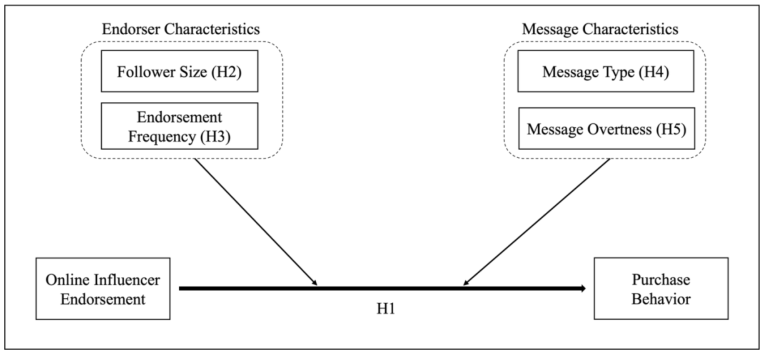

NOTE: figure/graphic rendered as an image from the PDF; its content is not machine-readable text. Caption (if any) follows as the next block.

**Figure 1.** Research Framework

#### **4.1 Online Influencer Endorsement**

Consumers’ behavioral responses to online influencer endorsements can be understood through the lens of

persuasion theories in literature, including social influence theory, the elaboration likelihood model (ELM), and

the stimulus-organism-response (SOR) model (Chen 2023, Kelman 2017, Mehrabian and Russell 1974, O’Keefe

Page 11

2013). According to social influence theory, individuals are more prone to adopt the opinions of those they like,

feel familiar with, and identify as similar (Kelman 2017). The ELM proposes that persuasion operates through

two distinct routes: a central route, where motivated and able consumers carefully evaluate message content, and

a peripheral route, where consumers with lower motivation or ability rely on cues such as the endorser’s credibility

or attractiveness (O’Keefe 2013). The SOR model further suggests that online influencer endorsements function

as stimuli that evoke emotional and cognitive responses in consumers, which in turn shape their purchase behavior

(Chen 2023, Mehrabian and Russell 1974).

Prior research has consistently demonstrated that both celebrity and influencer endorsements positively influence

consumer attitudes, enhance purchase intentions, and even drive actual sales (Chung et al. 2013, De Veirman et

al. 2017, Elberse and Verleun 2012, Jin and Phua 2014, Silvera and Austad 2004). Building on the above

theoretical and empirical foundations, we hypothesize that online influencer endorsement on social media has a

positive impact on product sales:

*H1: Online influencer endorsement on social media significantly increases product sales.*

#### **4.2 Endorser Characteristics**

#### *Follower Size*

Industry practitioners recognize that not all online influencers can effectively persuade consumers (Wies et al.

2023). This is in stark contrast to the case of celebrity endorsement, where the endorsers often possess broad

recognition and established appeal. As such, marketing practitioners must carefully select influencers who can

effectively engage their target audience (Gu et al. 2024). According to the Source Credibility Model, consumers

are more likely to be persuaded by attractive influencers (Erdogan 1999, Kahle and Homer 1985, Spry et al. 2011).

In the context of online influencer, follower size serves as a visible indicator of popularity and attractiveness (De

Veirman et al. 2017). Moreover, source credibility has been found to influence attitude by affecting the own-

thought activation process in cognitive response (Harmon and Coney 1982). A highly credible source inhibits

own-thought activation, leading message receivers to rely on the information presented in the endorsement

message, rather than making judgement basing on the information previously stored in one’s memory (Greenwald

1968). Thus, when an influencer is perceived as more credible—reflected in a higher follower size—consumers

are more likely to respond positively to the endorsement.

Page 12

*H2: The positive impact of online influencer endorsement on product sales is further enhanced when the online*

*influencer has a larger follower size.*

#### *Endorsement Frequency*

The perceived credibility of the online influencer can also be influenced by the endorsement frequency of the

online influencer. Endorsement frequency is defined as the proportion of an influencer’s social media posts that

are product endorsements. Endorsement frequency is closely linked to the trustworthiness dimension within the

Source Credibility Model. Prior research indicates that when celebrities endorse too many products, it undermines

their perceived credibility (Tripp et al. 1994). This is because the frequent endorsements create the impression

that the online influencer is extrinsically motivated by financial gain (Cheng et al. 2020). Therefore, we argue that

product endorsement by an online influencer with a high frequency of endorsements leads to a lower level of

perceived credibility, which weakens the impact of the endorsement on sales:

*H3: The positive impact of online influencer endorsement on product sales is weakened when the online*

*influencer’s endorsement frequency is high.*

#### **4.3 Message Characteristics**

#### *Message Type*

Endorsement messages on social media platforms can appear either as text-only or as imagery (i.e., text-and-

image posts). Information processing theory suggests that individuals have a limited capacity to process incoming

stimuli (Simon 1994). When the amount of information received exceeds the individual’s processing capacity, the

individual is likely to experience information overload (Lee and Lee 2004). In response, individuals may

“compress, aggregate, categorize, and structure information” for easy processing (Eppler and Mengis 2004, pp.

335). Another coping strategy is to turn to less complex information like visuals (Chan 2001, Lewis et al. 2013),

because images are more salient cues that can quickly capture the attention of the audience (Lin and Boh 2021).

This is also consistent with attention economy theory, which suggests that individuals' attention is a limited

resource (Davenport and Beck 2001, Falkinger 2008). The issue of limited information capacity is particularly

salient in the context of social media. With the ever-increasing amount of information on social media platforms,

users are less able to process and pay attention to each piece of information. Messages, including endorsement

messages, appearing on social media platforms compete for users' attention (Falkinger 2008). Under conditions

of information overload, consumers are more likely to process less complex information presented in a more

Page 13

salient manner, such as visual messages, rather than textual messages which require more cognitive effort to

process (Sanbonmatsu and Kardes 1988).

The presence of image in the endorsement message can be a salient cue that enhances the effectiveness of the

endorsement for two reasons. First, the presence of an image might be more likely to capture viewers’ attention.

Early results from Pieters and Wedel (2004) using eye-tracking data on print advertisements have shown that

image component can capture readers’ baseline attention. Secondly, viewers may appreciate the extra effort put

into creating imagery posts compared to text-only posts. This effort may serve as an additional cue for determining

the credibility of the source (Kruger et al. 2004). Additionally, a study of image content and social media

engagement found a significant positive effect of image presence on user engagement. The results were robust

across different product categories and platforms (Li and Xie 2020). Hence, visuals in endorsement messages

enhance the persuasive power of communication, particularly when recipients are less motivated to process

detailed information. Once attention is secured, visuals complement the textual component by facilitating

information processing rather than imposing additional cognitive demands. Miniard et al. (1991) suggest that

imagery messages increase product evaluations when recipients are less motivated to process the information

presented. This is due to the higher level of message diagnosticity perceived by recipients exposed to visuals

compared to being exposed to text alone (Jiang and Benbasat 2007). Therefore, we argue that imagery

endorsement messages incorporating both text and visuals are more effective in capturing consumer attention and

enhancing message diagnosticity, thereby strengthening endorsement effectiveness:

*H4: The positive impact of online influencer endorsement on product sales is strengthened when the online*

*influencer endorsement is imagery.*

#### *Message Overtness*

Unlike livestream commerce, where influencers overtly promote products in a virtual showroom and directly

encourage purchases, the overtness level of endorsement messages on Twitter-liked social media varies

considerably. We argue that the effectiveness of online endorsements is shaped by the degree of message overtness.

Overtness refers to the extent to which consumers perceive the endorsement message as a deliberate and

persuasive effort. Overt endorsement messages are clearly promotional and sponsored, while covert endorsement

messages have a more subtle promotional intention (Chan 2020). From the source credibility perspective, covert

endorsements are more likely to be perceived as non-sponsored casual sharing of a good product. The covert

endorsement message thus is perceived to be more trustworthy in terms of the functionality and quality of the

Page 14

product. This is consistent with the persuasion knowledge model, which argues that ambiguous cues (covert

endorsement) are less suspicious of firms’ manipulative intentions compared to salient cues (overt endorsement)

(Kirmani and Zhu 2007). Therefore, covert endorsements are expected to be more effective in influencing

consumer behavior than overt endorsements. Literature also found evidence that overt endorsement messages

have a negative impact on purchase intention. For example, Liljander et al. (2015) found that overt marketing in

blog posts had a detrimental effect on consumers' purchase intentions. In a laboratory setting, Hwang and Jeong

(2016) found that simple disclosure of sponsorship, where a simple sponsorship message was provided in the blog

post, like “Sponsored post”, led to negative source credibility perceptions and message attitudes. Similarly, Chan

(2020) found that covert promotions delivered through third parties were perceived as more believable, resulting

in more positive evaluations of the promoted brand.

Nevertheless, the context of online influencer endorsements on social media presents a different dynamic. Unlike

blogs or traditional media, social media platforms are characterized by severe information overload, where users

are overwhelmed by a continuous stream of competing content. As discussed, because of individuals’ limited

capacity in information processing, social media posts are competing for users’ attention. According to

Information Processing Theory, individuals prefer to rely on simple and direct cues when the incoming stimuli

exceed the information processing capacity as a coping mechanism (Simon 1994). In this environment, covert

endorsements, though potentially more trustworthy, may fail to capture sufficient attention or clearly convey the

promotional message. In contrast, overt endorsements convey a direct message that is much easier to process and

understand, increasing awareness of the endorsed product and enhancing message diagnosticity. Thus, we argue

that overt endorsements are more likely to attract user attention in the high-competition context, thereby

strengthening endorsement effectiveness:

*H5: The positive effect of online influencer endorsement on product sales is strengthened when the online*

*influencer endorsement is overt.*

### **5. Methodology**

#### **5.1 Data collection**

Our data was collected during the period from September 28<sup>th</sup>, 2016 to October 31<sup>st</sup>, 2016. We collected both

online influencer activities and the corresponding sales data. The online influencer endorsement data was collected

Page 15

from Weibo, a Chinese social media site similar to Twitter and Facebook. Originally launched as China’s Twitter,

Weibo gradually incorporated features of Facebook by allowing users to post longer messages embedded with

multimedia, such as images, hyperlinks, and videos. With its 300 million users and 130 million daily active users

during the data collection period, Weibo was the dominant social media platform in China, making it an ideal

choice for our research. Other platforms like TikTok (Douyin) and Xiaohongshu (Little Red Book or RED) were

not as prominent at that time. The sales data was collected from Taobao and Tmall, both subsidiaries of Alibaba,

the leading e-commerce company in China.

To ensure the generalizability of our findings, we chose to focus on a diverse range of online influencers across

six categories that are more likely to endorse a product, including food and drink, beauty, makeup bloggers,

celebrities, athletes, and sports. We extracted the top 200 influencers based on the number of followers from each

category. Ten research assistants were recruited to assist with data collection. Each research assistant was assigned

240 accounts to track daily posts for one month, making sure each influencer was tracked by two research

assistants. The research assistants were required to follow the assigned influencers on Weibo and read their posts

each day. Any post that mentioned a product, whether through text or visuals, and regardless of the explicitness

of the promotion, was recorded as an endorsement activity and submitted to our dedicated data collection system

at the end of each day. Figure 2 provides an example of an endorsement activity that includes both text and image

in the endorsement message.

[figure not shown]

NOTE: figure/graphic rendered as an image from the PDF; its content is not machine-readable text. Caption (if any) follows as the next block.

Page 16

**Figure 2.** An Influencer’s Endorsement Activity

Once an endorsement was found, the research assistant would proceed to find the endorsed product. If there was

a product link to Taobao or Tmall in the endorsement message, the research assistant would record the link in

their submission in our data collection system. If there was no product link in the endorsement, the research

assistants were required to search for the product name on Taobao and record the first product in the search results

as the product link of an endorsement. Search results in Taobao include products sold on both platforms, Tmall

and Taobao. We also asked the research assistant to identify a similar product from the recommendation list

displayed on the product page as the control group in the DID analysis. The selection of similar products was

based on product category, brand, store, and price. A similar product must meet three criteria: (1) it is in the same

product category and sold by the same store; (2) it has the same brand; and (3) has a price within 20% of the

endorsed product. The similar product represents a control product that is similar to the endorsed product in

various ways (e.g., brand, functionality, etc.), except that it is a product not endorsed by the influencer on the

social media platform.

Each day during the data collection period, research assistants were required to read all the posts posted on that

day and report endorsement activities and product links before midnight that day. Data collection scripts were

then automatically launched at midnight to extract data from product pages. Sales data, inventory information,

ratings, buyer comments, and other product-related information were collected for all the endorsed products as

well as the similar products. For each of the online influencer endorsement identified by our research assistants,

we collected data from the product page for 30 days to monitor the change in sales.

We also used Weibo's API service to retrieve online influencers' Weibo account information including number of

followers. Not all online influencer accounts have endorsement activities during the data collection period. Finally,

1311 endorsement activities were identified by our research assistants during the data collection period. 527

endorsement activities were removed due to incomplete data. Some of the endorsed products were removed from

Taobao or Tmall before we completed the 30-day sales monitoring. In total, we collected 784 endorsement

activities from 165 celebrities.

#### **5.2 Measures**

*Dependent variable.* We used 30-day sales data published on the product page to estimate the impact of the

endorsements. Our dependent variable, monthly sales, is defined as the number of products sold in the past 30

Page 17

days.<sup>2</sup> For each product endorsement *i* identified by our research assistant, we recorded the sales data we collected

on Day 1 (immediately after the endorsement) as the monthly sales before the endorsement. We then recorded the

sales data we collected on Day 30 as the monthly sales after the endorsement. For each product endorsement, we

also used the similar product for comparison (aka, control group).

*Endorser characteristics.* We examine two endorser characteristics: follower size and endorsement frequency.

Follower size of online influencers serves as a visible indicator of popularity and attractiveness (De Veirman et

al. 2017). We measure *follower size* using the number of followers each influencer had at the time of the

endorsement activity (Leung et al. 2022a). Endorsement frequency affects users’ perceptions toward the

endorsement (Tripp et al. 1994). We measure *endorsement frequency* as the ratio of the number of product

endorsement posts to the total number of Weibo posts by the influencer in a 30-day window, as the total number

of posts within a time period varies across online influencers. A higher endorsement frequency indicates that a

greater share of the influencer’s content during that period was dedicated to product promotion.

*Message characteristics.* We examine two message characteristics: message type and message overtness. Text-

only and imagery messages differ in the demands they place on users’ information processing capacity (Lin and

Boh 2021, Miniard et al. 1991), while the overtness of the message influences users’ perceptions of source

credibility and message diagnosticity (Hwang and Jeong 2016, Liljander et al. 2015, Simon 1994). We use two

dummy variables to measure message characteristics of the endorsements. *Is Text* is used to indicate whether the

endorsement message contained only text or also contained pictures (1 if the message only contains text, and 0 if

the message contains picture). To measure if an endorsement message is overt or covert, we hired two additional

research assistants – who were not involved in the data collection task and were unaware of the purpose of our

study. We developed a coding scheme (see Table II) based on two established frameworks: the typology of masked

marketing practices (Petty and Andrews 2008) and the four-factor model of sponsorship transparency (Wojdynski

et al. 2018). The typology outlines six types of disguised communication, which helped operationalize overt versus

covert messages by aligning their characteristics, e.g., lack of apparent sponsorship for subtle categories versus

clear promotional intent for overt ones, with our scale. The four-factor model further differentiates advertising

messages into sponsorship transparent (overt) or non-transparent (covert) across four attributes: brand presence,

sponsor clarity, disclosure, and lack of deception. Building on the two frameworks, our coding scheme ranges

2 Total sales or daily sales data are not available on the product page.

Page 18

from 1 (extremely subtle) to 5 (extremely overt), with subtle messages defined by the presence of a product

without seeming like sponsored promotion, and overt messages identified by clear sponsorship alongside product

presence. After a brief training session, the two research assistants independently coded the endorsement messages.

Agreement between the two coders was 95.89%. We collapsed rating scores into a dummy variable (*Overt*) by

assigning 1 to endorsement messages coded as “extremely overt” and assigning 0 to the rest.

-- Insert Table II Here --

*Control variables.* A list of control variables is included in our model. *Site* is a dummy variable indicating where

the product link is from (1 for Tmall and 0 for Taobao). *Price* is the price of the product in Chinese yuan. We

also controlled for number of images (*Num Images*) and words (*Num Words*) in the product description. Finally,

we controlled for the product ratings in terms of their description (*Description Rating*, indicating whether the

product is same as the description), service (*Service Rating*), and logistics (*Logistic Rating*).

#### **5.3 Model**

We use the following model to test H1:

# 𝑆𝑎𝑙𝑒𝑠𝑖𝑡= 𝛼+ 𝛽∙𝐸𝑛𝑑𝑜𝑟𝑠𝑒𝑖+ 𝛾∙𝑃𝑜𝑠𝑡𝑡+ 𝛿<sup>′</sup> ∙𝐸𝑛𝑑𝑜𝑟𝑠𝑒𝑖𝑡∙𝑃𝑜𝑠𝑡𝑡+ 𝜃′ ∙𝑍𝑖𝑡+ 𝜀𝑖𝑡 (1)

**equation / math rendering (image)**

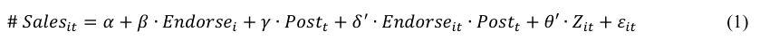

NOTE: contains mathematical notation; text above is the PDF text layer and symbols may be mis-extracted. Image shows the original.

In the above model, *# Salesit* is the monthly sales of product *i* on Day *t* (*t = 1* or *30*). 𝐸𝑛𝑑𝑜𝑟𝑠𝑒𝑖 equals 1 if *i* is an

endorsed product and 0 if *i* is a similar product that was not endorsed. 𝑃𝑜𝑠𝑡𝑡 equals 1 if *t = 30*, and 0 if *t = 1.* The

coefficient 𝛿<sup>′</sup> captures the effect of the online influencer’s endorsement. 𝑍𝑖𝑡 is a vector of control variables and

𝜃′ is a vector of the associated coefficients.

To test the moderation effect of endorser and endorsement message characteristics, we include endorser or

message-related variables in the interaction term in the following form:

# 𝑆𝑎𝑙𝑒𝑠𝑖𝑡= 𝛼+ 𝛽∙𝐸𝑛𝑑𝑜𝑟𝑠𝑒𝑖+ 𝛾∙𝑃𝑜𝑠𝑡𝑡+ 𝛿<sup>′</sup> ∙𝑉𝑎𝑟𝑖 ∙𝐸𝑛𝑑𝑜𝑟𝑠𝑒𝑖𝑡∙𝑃𝑜𝑠𝑡𝑡∙+𝜃′ ∙𝑍𝑖𝑡+ 𝜀𝑖𝑡 (2)

**equation / math rendering (image)**

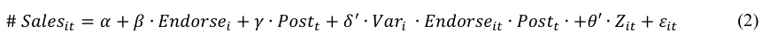

NOTE: contains mathematical notation; text above is the PDF text layer and symbols may be mis-extracted. Image shows the original.

where 𝑉𝑎𝑟𝑖 is a vector of endorser or message-related variables. For endorser characteristics, we use follower size

(*Num Followers,* in thousands) to test H2 and endorsement frequency (*EF*) to test H3. For message characteristics,

we use dummy variables *Is Text* and *Overt* to test H4 and H5, respectively.

### **6. Empirical Results**

#### **6.1 Main Results**

Page 19

Table III provides summary statistics for the main dependent variables and the control variables. Table IV shows

the empirical results. Model 1 examined the average effect of celebrity endorsement. We did not find significant

average effect of celebrity endorsement, as the interaction term Endorse × Post is not significant

(Endorse × Post = −1089.37, n. s.). Therefore, we did not find support for Hypothesis 1. This result is

**equation / math rendering (image)**

consistent with the industry observation that not all online celebrities have the ability to effectively increase sales.

It suggests that the impact of celebrity endorsement on sales is not universal and depends on various factors, such

as the characteristics of the endorser and the message being conveyed.

From Model 2 to Model 5, we examined different sets of endorser and message characteristics to test H2 to H5.

In Model 2, we found a significant effect of the endorsement, when the number of followers was included in the

model (Endorse × Post × Num Followers = 0.61,p < 0.01). This finding supports H2, indicating that the

**equation / math rendering (image)**

number of followers has a significant influence on the effectiveness of celebrity endorsement. Additionally, we

were able to quantify the economic value of the followers. Our estimation revealed that an increase of ten thousand

followers could lead to an increase of 6 units in sales. Considering that the average number of followers in our

dataset is approximately 1,500 thousand, this number holds substantial meaning and significance. In Model 3, we

found that as the online influencer increases the promotion frequency, the effect of endorsement is weakened

**equation / math rendering (image)**

In Model 4 and 5, we found significant findings regarding the effectiveness of imagery messages and overt

messages in increasing sales. Firstly, we observed that imagery messages had a much stronger impact. The

interaction effect in Model 4 was negative and significant (Endorse × Post × Is Text = −5680.37,p <

**equation / math rendering (image)**

0.001). This suggests that incorporating pictures in the messages significantly enhances their effectiveness in

increasing sales. In Model 5, we found that overt endorsement messages strengthened the endorsement effect. The

interaction effect was positive and significant (Endorse × Post × Overt = 2078.83, p < 0.05). Specifically,

**equation / math rendering (image)**

extremely overt endorsement message corresponds to a higher monthly sales number by about 2000 units on

average. H5 is supported.

-- Insert Table III Here --

-- Insert Table IV Here --

#### **6.2 Robustness Check with Matched Sample**

Page 20

To test the robustness of our results, we further employed Coarsened Exact Matching (Iacus et al. 2012) to match

the treated group (endorsed products) and control group (unendorsed products) on a set of controls variables (Num

Images, Num Words, Desc Rating, Service Rating, and Logistic Rating). CEM coarsen each variable into broader

categories or bins. After coarsening, CEM performs exact matching on the coarsened variables. Once the matching

is completed, the original values of the matched data are used for further analysis. We followed the default Sturges’

rule when performing the matching (Ozer et al. 2023). We have 107 matched strata out of 237 strata, resulting in

a matched sample of 2,625 observations. Table V shows the multivariate L1 distance before and after the

matching. As we can see, the CEM have significantly reduced the imbalance between the treatment and control

group, especially for the rating variables (38% reduction of the L1 distance), indicating the effectiveness of the

matching. We then used this matched sample to re-estimate the models. The estimated results are presented in

Table VI and are consistent with the main results.

-- Insert Table V Here –

-- Insert Table VI Here –

### **7. Robustness Test using Comments as a Proxy of Sales**

One of the challenges to our main analysis is that we relied on monthly sales data on day 1 and day 30, because

Taobao/Tmall only reports monthly sales data rather than total sales data or daily sales. As a robustness test to the

main analysis, we turn to the cumulative number of comments on the product pages in Taobao/Tmall as a proxy

for the cumulative sales number. Taobao/Tmall only allows buyers who complete the transactions to post

comments for the product they have purchased. If we assume that the fraction of the buyers who post comments

after purchasing the product remains relatively stable, then the number of comments is proportional to the sales

number.<sup>3</sup>

In the robustness test, our focus is on the daily growth of the cumulative comments. We assume that the daily

growth of the comments is influenced by a similar set of control variables. Additionally, we hypothesize that there

3 Some media have reported that about 1~2 percent of buyers would post review comments. Our analysis would not be affected by the actual percentage as long as the percentage is relatively stable over time.

Page 21

is a difference between the endorsed group and the control group in terms of the daily growth of comments.

Specifically, the model is:

𝑙𝑛(𝐺𝑟𝑜𝑤𝑡ℎ{𝑖𝑡}) = 𝛽0 + 𝛽1𝑒𝑛𝑑𝑜𝑟𝑠𝑒𝑖+ 𝜷′𝒅 𝐷𝑖𝑡+ 𝜷′𝒄𝑪𝒐𝒏𝒕𝒓𝒐𝒍𝒊𝒕+ 𝜇𝑖,𝑡 (3)

**equation / math rendering (image)**

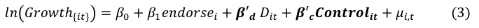

NOTE: contains mathematical notation; text above is the PDF text layer and symbols may be mis-extracted. Image shows the original.

where 𝐺𝑟𝑜𝑤𝑡ℎ{𝑖𝑡} = 𝐶𝑜𝑚𝑚𝑒𝑛𝑡𝑠𝑡 𝐶𝑜𝑚𝑚𝑒𝑛𝑡𝑠𝑡−1 ⁄ , is the comment growth rate of sample *i* at day *t*. 𝑒𝑛𝑑𝑜𝑟𝑠𝑒𝑖=1

**equation / math rendering (image)**

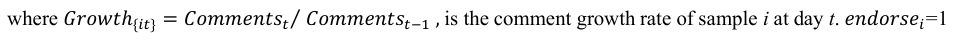

NOTE: contains mathematical notation; text above is the PDF text layer and symbols may be mis-extracted. Image shows the original.

indicates the sample 𝑖 is an endorsed product. 𝐷𝑖𝑡 is a 28 × 1 row<sup>4</sup> vector of dummy coding with only the 1 in the

*t* element and 𝜷′𝒅 is a vector of the corresponding coefficients. 𝑪𝒐𝒏𝒕𝒓𝒐𝒍𝒊𝒕 is a vector of controls similar to the

main analysis and 𝜷′𝒄 is a vector of the corresponding coefficients. 𝜇𝑖,𝑡 is the error that is not captured by the

model.

Table VII shows the results for the robustness test. Model 1 is the baseline model that tests the impact of

endorsement on the comment growth rate. Model 2 incorporates control variables in addition to endorsement. In

Model 3 we interact endorsement and day index dummies. From Model 1, we observe that the coefficients on the

day index dummies are negative, indicating a declining daily sales volume over time. It is difficult for products

to maintain stable sales over time due to competition or other factors such as seasonal effects. The effect of the

endorsement is significantly positive (Endorse = 0.0096, p < 0.001), indicating the effectiveness of online

influencer’s endorsement. Model 2 shows the similar findings when the control variables are included.

In Model 3, the interaction between endorsement and each day index dummy was examined. We only observed

one significantly positive coefficient on day 4 (Day_Index = 4 × Endorse = 0.015, p < 0.1). This indicates

**equation / math rendering (image)**

that there was a noticeable increase in the number of comments on day 4 after the online influencer endorsement.

This finding is reasonable, as it is often expected that the impact of sales, reflected by the number of comments,

may be delayed.

-- Insert Table VII here --

### **8. Discussions and Implications**

While prior research has focused on offline and online celebrity endorsements using purchase intention as a proxy,

our study aims to examine the impact of online influencer endorsement on actual purchase behavior, with a focus

4 The first day is the base period so it does not have the growth rate data. For dummy coding, Day 2 is our based period, leaving us with only 28 dummies.

Page 22

on endorsers and messages characteristics. We find no direct association between endorsements and sales,

highlighting the importance of these characteristics in the online influencer endorsement process. We draw on the

source credibility model and information processing theory to theorize and empirically test how these

characteristics moderate endorsement effectiveness.

First, we've identified the follower size as a critical determinant of the effectiveness of an endorsement. This

confirms that attractive endorsers are more effective in persuading potential consumers to purchase the product,

because consumers view the follower size as an indicator of the source's credibility (Jin and Phua 2014). We

further quantified the effect of follower size and found that for every ten thousand additional followers, product

sales could increase by approximately six units. Academic research and industry reports have highlighted

distinctions among influencer tiers (Cascio Rizzo et al. 2023b). Online influencers with fewer than ten thousand

followers have been described as the nano-influencers (Lee and Junqué de Fortuny 2022). Our research provides

some empirical support for this cutoff that micro-influencers are those likely to lead to material sales. We also

address mixed findings in the impacts of micro- and macro- influencers on endorsement effectiveness. While

experiments suggest micro-influencers excel at increasing purchase intention (Park et al. 2021, Kay et al. 2020),

our results indicate macro-influencers are more effective at generating actual sales in a social media context. These

insights have practical implications for businesses, offering guidance on optimizing influencer marketing

strategies and assessing the cost-effectiveness of different influencer tiers for product promotion.

Second, we find that frequent endorsement of products by an online influencer reduces the effectiveness of the

endorsements. This aligns with the Source Credibility Model, as excessive endorsements diminish the endorser's

credibility. It is also consistent with recent findings that repeated endorsements by online influencers have little

impact on product sales (Geng et al. 2024). Thus, endorsers face a trade-off: endorsing more products may boost

short-term income but can harm their credibility, potentially jeopardizing future opportunities. This finding also

highlights the importance for companies to consider an influencer's recent endorsement frequency, alongside their

follower size, when selecting endorsers.

Third, our findings also highlight the significant role of information overload in the mechanism of the online

influencer endorsements. Given the prevalence of information overload on social media and the dominance of

heuristic decision-making, we find that imagery and overt endorsements are more effective than text-only and

covert endorsements, respectively. According to Information Processing Theory, individuals tend to rely on

simple and easy-to-process information when making decisions as a coping mechanism. Contrary to the findings

of Hwang and Jeong (2016) and Chan (2020), we discovered that overt messages are indeed more effective in

Page 23

persuading viewers to purchase products. We attribute this finding to the unique environment of social media,

where information overload is more pronounced. In the context of online influencer endorsements on social media

platforms, endorsement messages compete for consumer attention. Overt endorsements deliver a direct message

that is easier to process and understand, thereby enhancing product awareness. These findings also speak to the

growing literature and practice of stealth marketing. One of the reasons marketers engage in stealth marketing is

that consumers react negatively to overt marketing (Liljander et al. 2015). However, our results suggest that this

concern may be less relevant in the social media environment, where individuals simply process the endorsement

messages as cues. In this process, the awareness effect of stealth marketing, which informs consumers about the

existence of the product, outweighs the persuasive effect, which conveys about the trustworthiness of the

endorsement. Consequently, direct and easy-to-process marketing messages are actually more effective in

persuading consumers.

Our study presents significant theoretical implications. Firstly, we propose a framework to investigate the

moderating factors that influence the effectiveness of online influencer endorsements on actual sales, considering

both endorser and message characteristics. Our findings reveal that the persuasion mechanism differs in the social

media context due to information overload. Unlike traditional mass media, where consumers encounter limited

content, social media platforms overwhelm users with vast information. This phenomenon alters the way

consumers process and respond to influencer endorsements, necessitating a re-evaluation of existing persuasion

models. Our study contributes to this re-evaluation by demonstrating the nuanced effects of information overload

on consumer decision-making processes. Secondly, we quantify the impact of online influencer endorsement on

actual sales (behavioral response), ranging from micro- to macro-influencers. This addresses a critical gap in

literature, where previous studies have primarily examined the effects of celebrity/online influencer endorsement

on consumer attitudes and purchase intentions (internal responses) in lab or survey settings.

Our work differs from and complements existing studies on livestream commerce (Beichert et al. 2024, Gu et al.

2024, Zhang et al. 2024), where influencers promote products on platforms that enable seamless in-stream

purchases. By contrast, our cross-platform setting requires viewers to navigate from a social media site to an e-

commerce site, imposing extra cognitive effort on decision making. Under such conditions, consumers are more

likely to rely on salient cues when making decisions, consistent with the ELM model. Our empirical results

strongly support this previously unexplored argument. In addition, while prior livestream studies typically

examine either endorser or message characteristics in isolation, our study considers both, incorporating message

type and message overtness as distinctive features. Finally, our design allows for a direct comparison of sales

Page 24

outcomes between endorsed and non-endorsed products, providing stronger evidence of endorsement

effectiveness.

Our study also offers several practical implications for marketers and firms that invest heavily in influencer

campaigns. By analyzing data from the field, we provide robust evidence on how influencer endorsements

translate into measurable sales outcomes, thereby increasing the managerial relevance of our findings. First, our

results suggest that online celebrity endorsement alone is not a guarantee of sales impact. In particular, influencers

with fewer than ten thousand followers are unlikely to generate substantial sales. This indicates that marketers

should carefully evaluate the cost-benefit trade-off when collaborating with micro-influencers. Second,

endorsement frequency emerges as a critical strategic consideration. Our findings show that when influencers

dedicate too large a share of their posts to endorsements, whether for the same or different product, their credibility

diminishes, reducing the effectiveness of the endorsements. Marketers should therefore aim for a balanced

approach that safeguards authenticity and prevents audiences from perceiving influencers as overly

commercialized. Third, message characteristics play an equally important role. We find that overt, imagery

endorsement messages outperform covert, text-only ones in driving sales. This implies that clear, salient, and

visually engaging promotions are more effective in capturing attention and motivating purchase decisions. For

practitioners, this means that collaboration with influencers should not only focus on who delivers the message

but also on how the message is presented. By integrating both endorser- and message-level strategies, marketers

can better allocate resources, improve return on investment in influencer marketing, and achieve stronger sales

outcomes.

Beyond marketers, our findings also carry implications for platforms, influencers, and consumers. Platforms can

foster healthier engagement by enhancing transparency through clear labeling of endorsements, providing

analytics to help manage posting balance, and discouraging excessive commercialization through algorithm

design. Influencers need to balance promotional and non-promotional posts and present endorsements

authentically to preserve long-term audience trust. Consumers benefit when endorsements are transparent. Clear,

overt messages help them make more informed decisions, while a balanced volume of promotions reduces

persuasion fatigue and preserves the trustworthiness of influencer relationships. Together, these practices

contribute to a more sustainable influencer marketing ecosystem that balances commercial effectiveness with

authenticity and consumer trust.

Page 25

### **9. Limitations and Future Research**

Our study has several limitations. First, our empirical analysis is constrained by data availability. The

Taobao/Tmall platform only discloses sales data over a rolling 30-day window, which prevents us from observing

daily sales fluctuations and capturing short-term dynamics. To partially address this limitation, we conducted a

robustness check using the daily number of product comments as a proxy for sales, which revealed that the

endorsement effects are most prominent in the initial days following the endorsement. Moreover, the DID design

in this study includes a control group of similar products that did not receive endorsements during the study period,

which helps to isolate the endorsement effect from other confounding influences such as seasonality and

marketing trends. Nonetheless, future research could benefit from access to more granular sales data or alternative

platforms to further validate and extend our findings. Second, despite training research assistants extensively to

identify endorsed products on Taobao/Tmall, some products may not have been accurately linked to the

influencer's endorsement. If this occurred, it would have likely minimized the observed effects, as non-endorsed

products would not have seen a sales boost. Third, our research focused on endorsements on a Twitter-like social

media platform, where content is primarily text- and image-based. With the rise of short-video platforms like

TikTok in recently years, we question whether our findings can be generalized to these platforms, where video

content is more eye-catching yet more time- and cognitively- intensive to process. Existing research on video-

based platforms largely centers on livestream commerce, which involves direct product promotion. Future

research could extend our work by examining the effectiveness of online influencer endorsements in short-video

formats which embed overt or covert promotional messages within entertainment or informational content, rather

than relying on direct product promotion. Understanding how the level of message explicitness in these short

videos influences sales could yield valuable insights into the evolving strategies of influencer marketing. Fourth,

while we analyzed endorsement activities from six types of influencers, our dataset was not exhaustive due to the

vast number of online influencers and the manual effort required for identification. While we believe the

theoretical framework is applicable across influencer types, future research could investigate how characteristics

of different influencer types and product categories moderate endorsement effectiveness. For example, research

might explore how influencers’ hedonic versus utilitarian appeal, or the hedonic and utilitarian attributes of

products, influence consumer decision-making in the context of influencer marketing.

### **References**

Page 26

Beichert, M., Bayerl, A., Goldenberg, J. and Lanz, A. (2024) 'Revenue generation through influencer

marketing', *Journal of Marketing,* 88(4), 40-63. Bergkvist, L. and Zhou, K. Q. (2016) 'Celebrity endorsements: a literature review and research agenda',

*International Journal of Advertising,* 35(4), 642-663. Bharadwaj, N., Ballings, M., Naik, P. A., Moore, M. and Arat, M. M. (2022) 'A new livestream retail

analytics framework to assess the sales impact of emotional displays', *Journal of Marketing,* 86(1), 27-47. Borchers, N. S., Hagelstein, J. and Beckert, J. (2022) 'Are many too much? Examining the effects of

multiple influencer endorsements from a persuasion knowledge model perspective', *International Journal of Advertising,* 41(6), 974-996. Breves, P. L., Liebers, N., Abt, M. and Kunze, A. (2019) 'The perceived fit between instagram

influencers and the endorsed brand: How influencer–brand fit affects source credibility and persuasive effectiveness', *Journal of Advertising Research,* 59(4), 440-454. Brison, N. T., Byon, K. K. and Baker III, T. A. (2016) 'To tweet or not to tweet: the effects of social

media endorsements on unfamiliar sport brands and athlete endorsers', *Innovation,* 18(3), 309- 326. Cascio Rizzo, G. L., Berger, J., De Angelis, M. and Pozharliev, R. (2023a) 'How sensory language

shapes influencer’s impact', *Journal of Consumer Research,* 50(4), 810-825. Cascio Rizzo, G. L., Villarroel Ordenes, F. J., Pozharliev, R., De Angelis, M. and Costabile, M. (2023b)

'How High Arousal Language Shapes Micro versus Macro Influencers’ Impact', *Journal of Marketing,* 88(4), 1-22. Chan, F. F. Y. (2020) 'The perceived effectiveness of overt versus covert promotions', *Journal of*

*Product & Brand Management,* 29(3), 321-334. Chan, S. Y. (2001) 'The use of graphs as decision aids in relation to information overload and

managerial decision quality', *Journal of Information Science,* 27(6), 417-425. Chen, M.-J. (2023) 'Antecedents and outcomes of virtual presence in online shopping: A perspective of

SOR (Stimulus-Organism-Response) paradigm', *Electronic Markets,* 33(1), 58. Cheng, Y., Mukhopadhyay, A. and Williams, P. (2020) 'Smiling signals intrinsic motivation', *Journal*

*of Consumer Research,* 46(5), 915-935. Chung, K. Y., Derdenger, T. P. and Srinivasan, K. (2013) 'Economic value of celebrity endorsements:

Tiger Woods' impact on sales of Nike golf balls', *Marketing Science,* 32(2), 271-293. Davenport, T. H. and Beck, J. C. (2001) *The attention economy: Understanding the new currency of*

*business,* Harvard Business Press. De Veirman, M., Cauberghe, V. and Hudders, L. (2017) 'Marketing through Instagram influencers: the

impact of number of followers and product divergence on brand attitude', *International Journal of Advertising,* 36(5), 798-828. De Veirman, M. and Hudders, L. (2020) 'Disclosing sponsored Instagram posts: the role of material

connection with the brand and message-sidedness when disclosing covert advertising', *International Journal of Advertising,* 39(1), 94-130.

Page 27

Elberse, A. and Verleun, J. (2012) 'The economic value of celebrity endorsements', *Journal of*

*Advertising Research,* 52(2), 149-165. Eppler, M. J. and Mengis, J. (2004) 'The concept of information overload: A review of literature from

organization science, accounting, marketing, MIS, and related disciplines', *The Information Society,* 20(5), 325-344. Erdogan, B. Z. (1999) 'Celebrity endorsement: A literature review', *Journal of Marketing Management,*

15(4), 291-314. Falkinger, J. (2008) 'Limited Attention as a Scarce Resource in Information‐Rich Economies', *The*

*Economic Journal,* 118(532), 1596-1620. Farivar, S., Wang, F. and Yuan, Y. (2023) 'Influencer marketing: A perspective of the elaboration

likelihood model of persuasion', *Journal of Electronic Commerce Research,* 24(2), 127-145. Feng, L., Hu, Y., Li, B., Stanley, H. E., Havlin, S. and Braunstein, L. A. (2015) 'Competing for attention

in social media under information overload conditions', *PloS One,* 10(7), e0126090. Fleck, N., Korchia, M. and Le Roy, I. (2012) 'Celebrities in advertising: looking for congruence or

likability?', *Psychology & Marketing,* 29(9), 651-662. Fu, S., Li, H., Liu, Y., Pirkkalainen, H. and Salo, M. (2020) 'Social media overload, exhaustion, and

use discontinuance: Examining the effects of information overload, system feature overload, and social overload', *Information Processing & Management,* 57(6), 102307. Geng, R., Chen, X. and Wang, S. (2024) 'Wear in or wear out: how consumers respond to repetitive

influencer marketing', *Internet Research,* 34(3), 810-848. Goldsmith, R. E., Lafferty, B. A. and Newell, S. J. (2000) 'The impact of corporate credibility and

celebrity credibility on consumer reaction to advertisements and brands', *Journal of Advertising,* 29(3), 43-54. Greenwald, A. G. (1968) 'Cognitive learning, cognitive response to persuasion, and attitude change',

*Psychological Foundations of Attitudes,* 1968, 147-170. Gu, X., Zhang, X. and Kannan, P. (2024) 'Influencer Mix Strategies in Livestream Commerce: Impact

on Product Sales', *Journal of Marketing,* 88(4), 64-83. Halder, D., Pradhan, D. and Chaudhuri, H. R. (2021) 'Forty-five years of celebrity credibility and

endorsement literature: Review and learnings', *Journal of Business Research,* 125(2021), 397- 415. Harmon, R. R. and Coney, K. A. (1982) 'The persuasive effects of source credibility in buy and lease

situations', *Journal of Marketing Research,* 19(2), 255-260. He, W. and Jin, C. (2022) 'A study on the influence of the characteristics of key opinion leaders on

consumers’ purchase intention in live streaming commerce: based on dual-systems theory', *Electronic Commerce Research,* 24(2), 1-31. Hovland, C. I., Janis, I. L. and Kelley, H. H. (1953) *Communication and persuasion,* Yale University

Press. Hsu, C. L., Lin, J. C. C. and Chiang, H. S. (2013) 'The effects of blogger recommendations on

customers’ online shopping intentions', *Internet Research,* 23(1), 69-88.

Page 28

Huang, Y. and Morozov, I. (2024) 'The Promotional Effects of Live Streams by Twitch Influencers

(April 22, 2024)', *Available at SSRN: https://ssrn.com/abstract=4065064 or http://dx.doi.org/10.2139/ssrn.4065064*. Hughes, C., Swaminathan, V. and Brooks, G. (2019) 'Driving brand engagement through online social

influencers: An empirical investigation of sponsored blogging campaigns', *Journal of Marketing,* 83(5), 78-96. Hwang, Y. and Jeong, S.-H. (2016) '“This is a sponsored blog post, but all opinions are my own”: The

effects of sponsorship disclosure on responses to sponsored blog posts', *Computers in Human Behavior,* 62(2016), 528-535. Iacus, S. M., King, G. and Porro, G. (2012) 'Causal Inference without Balance Checking: Coarsened

Exact Matching', *Political Analysis,* 20(1), 1-24. Infosino, W. J. (1986) 'Forecasting new product sales from likelihood of purchase ratings', *Marketing*

*Science,* 5(4), 372-384. Jiang, Z. and Benbasat, I. (2007) 'The effects of presentation formats and task complexity on online

consumers' product understanding', *MIS Quarterly,* 31(3), 475-500. Jin, S.-A. A. and Phua, J. (2014) 'Following celebrities’ tweets about brands: The impact of Twitter-

based electronic word-of-mouth on consumers’ source credibility perception, buying intention, and social identification with celebrities', *Journal of Advertising,* 43(2), 181-195. Kahle, L. R. and Homer, P. M. (1985) 'Physical attractiveness of the celebrity endorser: A social

adaptation perspective', *Journal of Consumer Research,* 11(4), 954-961. Kay, S., Mulcahy, R. and Parkinson, J. (2020) 'When less is more: the impact of macro and micro social

media influencers’ disclosure', *Journal of Marketing Management,* 36(3-4), 248-278. Kelman, H. C. (2017) 'Processes of opinion change' in *Attitude change*, Routledge, 205-233. Kim, D. Y. and Kim, H.-Y. (2021) 'Influencer advertising on social media: The multiple inference

model on influencer-product congruence and sponsorship disclosure', *Journal of Business Research,* 130(2021), 405-415. Kirmani, A. and Zhu, R. (2007) 'Vigilant against manipulation: The effect of regulatory focus on the

use of persuasion knowledge', *Journal of Marketing Research,* 44(4), 688-701. Kruger, J., Wirtz, D., Van Boven, L. and Altermatt, T. W. (2004) 'The Effort Heuristic', *Journal of*

*Experimental Social Psychology,* 40(1), 91-98. Lafferty, B. A. and Goldsmith, R. E. (1999) 'Corporate credibility’s role in consumers’ attitudes and

purchase intentions when a high versus a low credibility endorser is used in the ad', *Journal of Business Research,* 44(2), 109-116. Lee, B. K. and Lee, W. N. (2004) 'The effect of information overload on consumer choice quality in an

on‐line environment', *Psychology & Marketing,* 21(3), 159-183. Lee, J. A. and Eastin, M. S. (2020) 'I like what she’s# endorsing: The impact of female social media

influencers’ perceived sincerity, consumer envy, and product type', *Journal of Interactive Advertising,* 20(1), 76-91.

Page 29

Lee, J. K. and Junqué de Fortuny, E. (2022) 'Influencer-Generated Reference Groups', *Journal of*

*Consumer Research,* 49(1), 25-45. Leung, F. F., Gu, F. F., Li, Y., Zhang, J. Z. and Palmatier, R. W. (2022a) 'Influencer marketing

effectiveness', *Journal of Marketing,* 86(6), 93-115. Leung, F. F., Gu, F. F. and Palmatier, R. W. (2022b) 'Online influencer marketing', *Journal of the*

*Academy of Marketing Science,* 50(2), 1-26. Lewis, M., Whitler, K. A. and Hoegg, J. (2013) 'Customer relationship stage and the use of picture-

dominant versus text-dominant advertising: A field study', *Journal of Retailing,* 89(3), 263- 280. Li, Y. and Xie, Y. (2020) 'Is a Picture Worth a Thousand Words? An Empirical Study of Image Content

and Social Media Engagement', *Journal of Marketing Research,* 57(1), 1-19. Liao, J., Chen, K., Qi, J., Li, J. and Yu, I. Y. (2023) 'Creating immersive and parasocial live shopping

experience for viewers: the role of streamers' interactional communication style', *Journal of Research in Interactive Marketing,* 17(1), 140-155. Liljander, V., Gummerus, J. and Söderlund, M. (2015) 'Young consumers’ responses to suspected

covert and overt blog marketing', *Internet Research,* 25(4), 610-632. Lin, Y. and Boh, W. F. (2021) 'Informational cues or content? Examining project funding decisions by

crowdfunders', *Information & Management,* 58(7), 103499. Lin, Y., Yao, D. and Chen, X. (2021) 'Happiness begets money: Emotion and engagement in live

streaming', *Journal of Marketing Research,* 58(3), 417-438. Lou, C. and Yuan, S. (2019) 'Influencer marketing: How message value and credibility affect consumer

trust of branded content on social media', *Journal of Interactive Advertising,* 19(1), 58-73. Masuda, H., Han, S. H. and Lee, J. (2022) 'Impacts of influencer attributes on purchase intentions in

social media influencer marketing: Mediating roles of characterizations', *Technological Forecasting and Social Change,* 174(2022), 121246. Mehrabian, A. and Russell, J. A. (1974) *An approach to environmental psychology,* the MIT Press. Miller, F. M. and Allen, C. T. (2012) 'How does celebrity meaning transfer? Investigating the process

of meaning transfer with celebrity affiliates and mature brands', *Journal of Consumer Psychology,* 22(3), 443-452. Miniard, P. W., Bhatla, S., Lord, K. R., Dickson, P. R. and Unnava, H. R. (1991) 'Picture-based

persuasion processes and the moderating role of involvement', *Journal of Consumer Research,* 18(1), 92-107. Morwitz, V. G., Steckel, J. H. and Gupta, A. (2007) 'When do purchase intentions predict sales?',

*International Journal of Forecasting,* 23(3), 347-364. O’Keefe, D. J. (2013) 'The elaboration likelihood model', *The SAGE handbook of persuasion:*

*Developments in theory and practice*, 137-149. Ohanian, R. (1991) 'The impact of celebrity spokespersons' perceived image on consumers' intention to

purchase', *Journal of Advertising Research,* 31(1), 46-54.

Page 30

Ozer, G. T., Greenwood, B. N. and Gopal, A. (2023) 'Digital multisided platforms and women’s health:

An empirical analysis of peer-to-peer lending and abortion rates', *Information Systems Research,* 34(1), 223-252. Park, J., Lee, J. M., Xiong, V. Y., Septianto, F. and Seo, Y. (2021) 'David and Goliath: When and why

micro-influencers are more persuasive than mega-influencers', *Journal of Advertising,* 50(5), 584-602. Petty, R. D. and Andrews, J. C. (2008) 'Covert marketing unmasked: A legal and regulatory guide for

practices that mask marketing messages', *Journal of Public Policy & Marketing,* 27(1), 7-18. Petty, R. E., Cacioppo, J. T., Petty, R. E. and Cacioppo, J. T. (1986) *The Elaboration Likelihood Model*

*of Persuasion,* Springer. Pieters, R. and Wedel, M. (2004) 'Attention Capture and Transfer in Advertising: Brand, Pictorial, and

Text-Size Effects', *Journal of Marketing,* 68(2), 36-50. Rossiter, J. R. and Smidts, A. (2012) 'Print advertising: Celebrity presenters', *Journal of Business*

*Research,* 65(6), 874-879. Roy Dholakia, R. and Sternthal, B. (1977) 'Highly credible sources: Persuasive facilitators or persuasive

liabilities?', *Journal of Consumer Research,* 3(4), 223-232. Sanbonmatsu, D. M. and Kardes, F. R. (1988) 'The effects of physiological arousal on information

processing and persuasion', *Journal of Consumer Research,* 15(3), 379-385. Silvera, D. H. and Austad, B. (2004) 'Factors predicting the effectiveness of celebrity endorsement

advertisements', *European Journal of Marketing,* 38(11/12), 1509-1526. Simon, H. A. (1994) 'The bottleneck of attention: connecting thought with motivation' in *W. D.*

*Spaulding (Ed.), Integrative views of motivation, cognition, and emotion*, University of Nebraska Press, 1-21. Singer, B. D. (1983) 'The case for using ‘real people’in advertising', *Business Quarterly,* 48(4), 32-37. Spry, A., Pappu, R. and Bettina Cornwell, T. (2011) 'Celebrity endorsement, brand credibility and brand

equity', *European Journal of Marketing,* 45(6), 882-909. Statista (2025) 'Influencer Advertising - Worldwide', [online], available: https://www.statista.com/outlook/amo/advertising/influencer-advertising/worldwide [Accessed January 15 2025]. Tam, K. Y. and Ho, S. Y. (2006) 'Understanding the impact of web personalization on user information

processing and decision outcomes', *MIS Quarterly,* 30(4), 865-890. Tian, Z., Dew, R. and Iyengar, R. (2024) 'Mega or micro? Influencer selection using follower elasticity',

*Journal of Marketing Research,* 61(3), 472-495. Tripp, C., Jensen, T. D. and Carlson, L. (1994) 'The effects of multiple product endorsements by

celebrities on consumers' attitudes and intentions', *Journal of Consumer Research,* 20(4), 535- 547. Tybout, A. M., Calder, B. J. and Sternthal, B. (1981) 'Using information processing theory to design

marketing strategies', *Journal of Marketing Research,* 18(1), 73-79.

Page 31

Valsesia, F., Proserpio, D. and Nunes, J. C. (2020) 'The positive effect of not following others on social

media', *Journal of Marketing Research,* 57(6), 1152-1168. Waltenrath, A. (2024) 'Consumers’ ambiguous perceptions of advertising disclosures in influencer

marketing: Disentangling the effects on current and future social media engagement', *Electronic Markets,* 34(1), 8. Wies, S., Bleier, A. and Edeling, A. (2023) 'Finding goldilocks influencers: How follower count drives

social media engagement', *Journal of Marketing,* 87(3), 383-405. Wojdynski, B. W., Evans, N. J. and Hoy, M. G. (2018) 'Measuring sponsorship transparency in the age

of native advertising', *Journal of Consumer Affairs,* 52(1), 115-137. Yang, Y. and Ha, L. (2021) 'Why people use TikTok (Douyin) and how their purchase intentions are

affected by social media influencers in China: A uses and gratifications and parasocial relationship perspective', *Journal of Interactive Advertising,* 21(3), 297-305. Yuan, S. and Lou, C. (2020) 'How social media influencers foster relationships with followers: The

roles of source credibility and fairness in parasocial relationship and product interest', *Journal of Interactive Advertising,* 20(2), 133-147. Zhang, G., Cao, J. and Liu, D. (2023) 'Examining the influence of information overload on consumers’

purchase in live streaming: A heuristic-systematic model perspective', *Plos One,* 18(8), e0284466. Zhang, S. K., Tang, T. Y. and Krallman, A. (2024) 'Navigating livestream commerce: A dual-lens

framework of influencers’ impact on product sales', *Journal of Business Research,* 185(2024), 114919. Zhang, Y. and Goh, K. H. (2018) 'Attracting versus sustaining attention in the information economy',

in *In: Cho, W., Fan, M., Shaw, M., Yoo, B., Zhang, H. (eds) Digital Transformation: Challenges and Opportunities. WEB 2017. Lecture Notes in Business Information Processing*, Springer International Publishing, 1-14.

Page 32

**Table I** Review of Online Influencer Endorsement Literature

| Authors | Context | Endorserattributes | Messageattributes | Outcomes | Methods |
| --- | --- | --- | --- | --- | --- |
| Beichertetal (2024) . | Instagram | Followersize | Nil | Returnoninvestment | Empirical |
| Bharadwajetal (2022) . | Livestream | Nil | Facepresence;emotional | Sales(withinplatform) | Empirical |
|  |  |  | displays | Perceivedcredibility; |  |
| Brevesetal (2019) . | Instagram | Influencer-brand fit | Nil | brandevaluation; | Survey |
|  |  |  |  | behavioralintention |  |
| CascioRizzoetal . | Multiplesocialmedia |  |  | Engagement;purchase |  |
| (2023a) | platforms | Followersize | Sensorylanguage | intention | EmpiricalandExperiment |
| CascioRizzoetal . | Multiplesocialmedia |  |  |  |  |
| (2023b) | platforms | Followersize | Languagearousal | Engagement | EmpiricalandExperiment |

NOTE: table converted from PDF layout to HTML text; cell boundaries are reconstructed. See PDF if exact alignment matters.

Page 33

| DeVeirmanetal (2017) . | Instagram | Followersize | Nil | Influencerlikeability | Experiment |
| --- | --- | --- | --- | --- | --- |
| DeVeirmanandHudders |  |  |  |  |  |
| (2020) | Instagram | Sourcecredibility | Sponsorshipdisclosure | Brandattitude | Experiment |
| Guetal (2024) . | Livestream(TikTok) | Followersize; | Nil | Sales(withinplatform) | Empirical |
|  |  | Numberofinfluencers; | Cognitivesocialcallto |  |  |
| Guoetal (2024) . | Livestream(Taobao) | Nil | actions;Affectivesocial | Sales(withinplatform) | Empirical |
|  |  | Influencerattractiveness; | calltoactions |  |  |
| HeandJin(2022) | Socialmediausers | expertise;trustworthiness | Nil | Purchaseintention | Survey |
|  |  | Influencer |  |  |  |
| Hsuetal (2013) . | Socialmediausers | trustworthiness; | Nil | Purchaseintention | Survey |
| HuangandMorozov |  | reputation |  |  |  |
| (2024) | Livestream(Twitch) | Nil | Nil | Videogameusage | Empirical |

NOTE: table converted from PDF layout to HTML text; cell boundaries are reconstructed. See PDF if exact alignment matters.

Page 34

| Hughesetal (2019) . | Motherhood | Influencerexpertise | Hedonicvalue | engagement | Empirical |
| --- | --- | --- | --- | --- | --- |
| JinandPhua(2014) | Socialmediausers | Followersize | Postvalence | Purchaseintention | Experiment |
| Kayetal (2020) . | Socialmediausers | Followersize | Sponsorshipdisclosure | Purchaseintention | Experiment |
| KimandKim(2021) | Socialmediausers | Nil | Sponsorshipdisclosure | Productattitude | Experiment |
|  |  |  |  | Attitudetoward |  |
| LeeandEastin(2020) | Instagram | Perceivedsincerity | Nil | influencer;brandattitude; | Experiment |
|  |  | Influenceractivity; | Postpositivity;sponsor | Purchaseintention |  |
| Leungetal (2022a) . | Weibo | influenceroriginality; | salience;newproduct | engagement | Empirical |
|  |  | followersize | launch |  |  |
| Liaoetal (2023) . | Sociamediausers | Influencerexpertise | Nil | Purchaseintention | Survey |

NOTE: table converted from PDF layout to HTML text; cell boundaries are reconstructed. See PDF if exact alignment matters.

Page 35

| Linetal (2021) . | Livestream | Influenceremotion | Nil | Engagement | Empirical |
| --- | --- | --- | --- | --- | --- |
|  |  | Trustworthiness; |  | Perceivedtrust;brand |  |
| LouandYuan(2019) | Socialmediausers | attractiveness;similarity | Informativevalue | awareness;purchase | Survey |
|  |  | tofollowers |  | intentions |  |
| Masudaetal (2022) . | Socialmediausers | Influencerattractiveness; | Nil | Purchaseintention | Survey |
|  |  | expertise;trustworthiness | Hedonicvisutilitarian | Perceivedinfluencer |  |
| Parketal (2021) . | Socialmediausers | Followersize | consumption | authenticity | Experiment |
|  |  |  | Videofeatures: |  |  |
| Tianetal (2024) . | Livestream(TikTok) | Followersize | informational , | Engagement | Empirical |
|  |  | Followersize;numberof | entertaining socializing , |  |  |
|  |  | followees;perceived |  |  |  |
| Valsesiaetal (2020) . | Twitter | autonomy;perceived | Nil | Engagement | Experiment |
|  |  | influence |  |  |  |

NOTE: table converted from PDF layout to HTML text; cell boundaries are reconstructed. See PDF if exact alignment matters.

Page 36

| Wiesetal (2023) . | Instagram | Followersize | Contentcustomization | Engagement | EmpiricalandExperiment |
| --- | --- | --- | --- | --- | --- |
|  |  | Perceivedcredibility; |  |  |  |
| YuanandLou(2020) | Socialmediausers | perceivedfairness | Nil | Productinterest | Survey |
|  |  | Influencerlikeability; |  |  |  |
| Zhangetal (2024) . | Livestream(Diantao) | influencerexpertise | Nil | Sales(withinplatform) | Empirical |
| Thisstudy | WeiboandTaobao/Tmall | Followersize; | MessageFormat; | Sales (cross-platform) | Empirical |
|  |  | Endorsementfrequency | OvertvsConvert |  |  |

NOTE: table converted from PDF layout to HTML text; cell boundaries are reconstructed. See PDF if exact alignment matters.

Page 37

**Table II** Coding scheme for endorsement message

#### **From 1 to 5: extremely subtle to extremely overt**

1: Extremely subtle;

2: Moderately subtle;

3: Moderate;

4: Moderately overt;

5: Extremely overt

#### **Subtle**:

1. Has a product

2. Does not seem to be a sponsored promotion

3. Might induce viewers to buy the product

**Overt**:

1. Has a product

2. Appear to be a sponsored promotion

Page 38

**Table III** Summary statistics of the variables

[output not shown]

NOTE: table converted from PDF layout to HTML text; cell boundaries are reconstructed. See PDF if exact alignment matters.

*Notes: Summary statistics of Number Followers (in thousands), Endorsement Frequency, Is Text and Overt of the*

*endorsed products are only available for the endorsed group and reported under “before” columns.*

Page 39

**Table IV** Regression Results

[output not shown]

NOTE: table converted from PDF layout to HTML text; cell boundaries are reconstructed. See PDF if exact alignment matters.

Page 40

[output not shown]

NOTE: table converted from PDF layout to HTML text; cell boundaries are reconstructed. See PDF if exact alignment matters.

*Notes*. (1) *Standard Error* in parentheses. (2) *Num Followers* are in thousands. (3) Significance codes: * *p* <

0.05, ** *p* < 0.01, *** *p* < 0.001

Page 41

**Table V** Coarsened Exact Matching (CEM) Results

[output not shown]

NOTE: table converted from PDF layout to HTML text; cell boundaries are reconstructed. See PDF if exact alignment matters.

#### **Table VI Regression Results after Coarsen Exact Matching**

[output not shown]

NOTE: table converted from PDF layout to HTML text; cell boundaries are reconstructed. See PDF if exact alignment matters.

Page 42

**Table VII** Additional Analysis Results

[output not shown]

NOTE: table converted from PDF layout to HTML text; cell boundaries are reconstructed. See PDF if exact alignment matters.

Page 43

[output not shown]

NOTE: table converted from PDF layout to HTML text; cell boundaries are reconstructed. See PDF if exact alignment matters.

*Notes*. (1) *Standard Error* in parentheses. (2) *Num Followers* are in thousands. (3) Significance codes: <sup>+</sup> *p* <

0.1, * *p* < 0.05, ** *p* < 0.01, *** *p* < 0.001